# Predicting Wellness of Exercises

Zhengkan Yang

May 19, 2015

# Summary

In this project, we examined the effects of exercise behaviors on the exercise qualities, using the data of measurements collected from wearable devices. We applied two predictive algorithms-**decision tree** and **random forest**, and finally decided to use **random forest** with 13 variables resampled at each split as our final model, which has a cross-validation accuracy **0.99**.  
The final model shows that **roll_belt**, **yaw_belt** and **pitch_forearm** are the most influential variables impacting the quality of exercise.

# Load the libraries

For this exercise, we will primarily use `dplyr` for data manipulation, `caret` for model building, `ggplot2` for data visualization

```r
require(dplyr)
require(caret)
require(ggplot2)
```

# Read the Data

We did not delete userName variable because there could be user-level confounding effect which will impacts the response (for instance, some users may be more likely to give a better exercise than others)

```r
training <- read.csv('pml-training.csv', sep = ',',na.strings = c('','NA'))
training <- training[,-c(1,3:7)]
training$user_name <- factor(training$user_name)
```

# Data Exploration

In this section, we explore the datasets by plotting the distribution of variables and search for the irregularities which needs to be addressed by appropriate preprocessing method

## Missing Values

There are 67 variables each of which have 98% missing values. With such a high percentage of NAs, doing imputation would be both too **computationally costly** and **highly biased**. Including them in the data will also reduce model performance. Therefore, the best way is to **delete all of these variables**.

```r
missing_percent <- data.frame(VarName <- names(training), Pct <- 0.0)

for(i in 1:length(names(training))){
    missing_percent$Pct[i] <- sum(is.na(training[,i]))/nrow(training)
}
missing_percent <- missing_percent[,c(1,3)]
names(missing_percent) <- c('Vars','Pct')

#Delete all of the variables
training <- training[,-which(missing_percent$Pct > 0.5)]
```

## Variables with nearZero variance

The variables with much less unique values than the total number of observation, as well as a huge imbalance between the most frequent value and the second most frequent value, should be removed because they have insignificant predictive power.

To be more conservative and not losing too much information, I use **freqCut = 99/1** and **uniqueCut = 10** as cutoff points, which resulted in **24** variables to be removed.

```r
nsv <- nearZeroVar(training,saveMetrics=TRUE,freqCut = 99/1, uniqueCut=10 )
if (length(which(nsv$nzv)) > 0){
    training <- training[,-which(nsv$nzv)]
}
```

## Check response class balance

Imbalance check in response variable is conducted to see if balancing technique such as undersampling/oversampling methods need to be applied before modeling.  
As the result shows, there is not a huge imbalance among response levels. So we do not need to apply balancing methods.

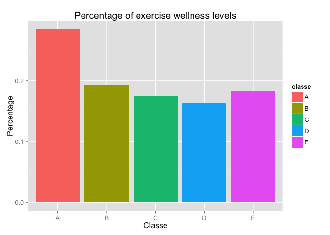

```r
training$classe <- factor(training$classe)
res_percent <- training %>% group_by(classe) %>% summarise(Percentage = n()/nrow(training))
ggplot(data=res_percent, aes(x = classe, y = Percentage)) + geom_bar(aes(fill = classe),stat='identity') + ggtitle('Percentage of exercise wellness levels') + xlab('Classe') + ylab('Percentage')
```

# Model Training and Selection

We applied two models here:  
*Decision Tree Classification* Random Forest

### Specify training control function

### Set up training control methods

```r
set.seed(123)
seeds <- vector(mode = "list", length = 51)
for(i in 1:50) seeds[[i]] <- sample.int(1000, 22)
fitControl <- trainControl(method = 'cv',number=10,allowParallel= TRUE,seeds=seeds)
```

### Classification Tree

```r
parGrid = expand.grid(cp = c(0.001,0.01,0.1))
CTree <- train(classe~.,data=training, trControl = fitControl, tuneGrid = parGrid,method = 'rpart')
final_tree <- CTree$finalModel
```

### Random Forest

```r
library(doMC)
registerDoMC(core=5)
number_of_var = length(names(training)) - 1
parGrid = expand.grid(mtry = c(floor(sqrt(number_of_var)),floor(number_of_var/3), floor(number_of_var/4)))
rForest <- train(classe~.,data=training,trControl = fitControl,tuneGrid=parGrid,method = 'rf',allowParallel = TRUE)
final_rForest <- rForest$finalModel
```

### Final Model Determination

The variable importance figure shows that the **roll_belt**, **yaw_belt** and **pitch_forearm** are the three most important variables determining the qualities of exercise.

```r
load('../.RData')
res_rf <- rForest$results[1,]
res_tree <- CTree$results[1,]
metrics <- data.frame(Model=c('Random Forest','Decision Tree'),importance = rbind(res_rf[,2:5],res_tree[,2:5]))
metrics
```

```
          Model importance.Accuracy importance.Kappa importance.AccuracySD
1 Random Forest           0.9966364        0.9957452          0.0009968378
2 Decision Tree           0.9040877        0.8785978          0.0087942896
  importance.KappaSD
1        0.001261066
2        0.011148416
```

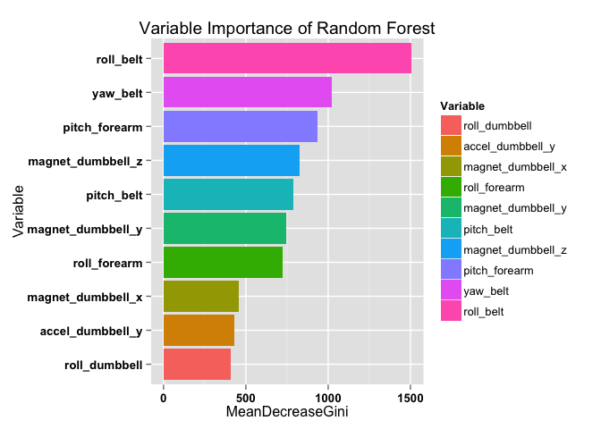

```r
final_rForest = rForest$finalModel
#Variable Importance
varImportance= data.frame(Variable = row.names(final_rForest$importance),final_rForest$importance)
varImportance = varImportance %>% arrange(desc(MeanDecreaseGini))

varImportance$Variable <- ordered(varImportance$Variable,levels = varImportance$Variable[order(varImportance$MeanDecreaseGini,decreasing=FALSE)])

ggplot(data=varImportance[1:10,],aes(x = Variable, y = MeanDecreaseGini)) + geom_bar(aes(fill = Variable),stat = 'identity') + coord_flip() + ggtitle('Variable Importance of Random Forest') + theme(axis.text = element_text(colour = 'black',face='bold',size=10))
```

## Model Testing

The best model is applied to 20 test cases to produce results

```r
testing <- read.csv('pml-testing.csv',na.strings = c('NA',''),header=TRUE)

answers = as.character(predict(rForest,newdata=testing))
pml_write_files = function(x){
    n = length(x)
   for(i in 1:n){
    filename = paste0("results/problem_id_",i,".txt")
    write.table(x[i],file=filename,quote=FALSE,row.names=FALSE,col.names=FALSE)
   }
 }
 pml_write_files(answers)
```